# TripsCaseStudyReport

Ahmad Ghozlan

2024-11-01

#### Business Task: To support Cyclistic’s goal of maximizing annual memberships, the marketing analytics team, under the direction of Lily Moreno, seeks to uncover key differences in usage patterns between casual riders and annual members. By analyzing these patterns, we aim to provide the executive team with data-driven recommendations that meet their high standards and equip the marketing department with insights to design effective campaigns that encourage casual riders to choose annual memberships.

#### Load data:

```r
# specifying the path of the folder on my pc
path <- "C:/Users/CLICK ONCE/OneDrive - Beirut Arab University/Documents/my_sheets/DataAnalytics/CaseStudyData/CSV"
#assigning a variable that represents a list that includes all files ending with
# .csv in the considered folder

csv_files <- list.files(path = path, pattern = "\\.csv$", full.names = TRUE)

# assigning a variable that contains all 12 data frames where each reresent one month

data_list <- lapply(csv_files, read.csv)

# Every variabe has the format yearMonth like 2310 relates to octorber 2023 and here is the clear range of each data frame.

df_2310 <- data_list[[1]]
df_2311 <- data_list[[1]]
df_2312 <- data_list[[3]]
df_2401 <- data_list[[4]]
df_2402 <- data_list[[5]]
df_2403 <- data_list[[6]]
df_2404 <- data_list[[7]]
df_2405 <- data_list[[8]]
df_2406 <- data_list[[9]]
df_2407 <- data_list[[10]]
df_2408 <- data_list[[11]]
df_2409 <- data_list[[12]]
```

## Adressing Bias, Credibility, and the ROCCC.

#### The data is sourced from the official Cyclistic trip website which is reputable and it meets the ROCCC standards. The data is **reliable** for its provided by the Cyclistic internal database known for thorough data logging and maintanance processes ensuring accuracy and minimizing errors. Logging directly every trip made by users ensures **originality**. The datasets are **comprehensive**, covering all trips performed by casual riders and annual members across a full calendar year, which allows us to analyze seasonal and daily trends effectively. The data is **current**, covering up to the most recent month, which provides relevant insights for today’s market and user behaviors. The data source is well-documented, **cited**, with clear guidelines ensuring transperancy in data collection methods.

#### Comprehensive: this dataset covers the entire year, capturing seasonal trends, making it comprehensive for analyzing user behavior.

```r
# Check that all data frames have the same columns
all_columns <- lapply(data_list, colnames)
identical(all_columns[[1]], all_columns[[2]]) # Sample pair-wise check for consistency
```

```
## [1] TRUE
```

#### Current: Data spans the last previous 12 months covering each month fully.

```r
# Load required library
library(lubridate)
# Define the start and end of the 12-month period
end_date <- as.Date("2024-10-31")  # Assuming we’re in early November 2023
start_date <- end_date %m-% months(11)  # Go back exactly 11 months from October to get November of the previous year

# Loop through each data frame in the list and check the date range
for (i in seq_along(data_list)) {
  # Convert started_at to Date format if not already
  data_list[[i]]$started_at <- as.Date(data_list[[i]]$started_at)

  # Find the minimum and maximum dates in started_at
  min_date <- min(data_list[[i]]$started_at, na.rm = TRUE)
  max_date <- max(data_list[[i]]$started_at, na.rm = TRUE)

  print(paste("Minimum date:", min_date, "Maximum date:", max_date))

}
```

```
## [1] "Minimum date: 2023-10-01 Maximum date: 2023-10-31"
## [1] "Minimum date: 2023-11-01 Maximum date: 2023-11-30"
## [1] "Minimum date: 2023-12-01 Maximum date: 2023-12-31"
## [1] "Minimum date: 2024-01-01 Maximum date: 2024-01-31"
## [1] "Minimum date: 2024-02-01 Maximum date: 2024-02-29"
## [1] "Minimum date: 2024-03-01 Maximum date: 2024-03-31"
## [1] "Minimum date: 2024-04-01 Maximum date: 2024-04-30"
## [1] "Minimum date: 2024-05-01 Maximum date: 2024-05-31"
## [1] "Minimum date: 2024-05-31 Maximum date: 2024-06-30"
## [1] "Minimum date: 2024-06-29 Maximum date: 2024-07-31"
## [1] "Minimum date: 2024-07-30 Maximum date: 2024-08-31"
## [1] "Minimum date: 2024-08-31 Maximum date: 2024-09-30"
```

#### This data set complies with the Cyclistic’s data sharing agreement. Sensitive information has been anonymized, ensuring user privacy.

#### Data integrity

```r
# Check for missing values
missing_values <- sum(is.na(df_2408))
print(paste("Missing values:", missing_values))
```

```
## [1] "Missing values: 2054"
```

```r
# Check for duplicate rows
duplicates <- sum(duplicated(df_2408))
print(paste("Duplicate rows:", duplicates))
```

```
## [1] "Duplicate rows: 0"
```

```r
# Check for missing values
missing_values <- sum(is.na(df_2409))
print(paste("Missing values:", missing_values))
```

```
## [1] "Missing values: 1506"
```

```r
# Check for duplicate rows
duplicates <- sum(duplicated(df_2409))
print(paste("Duplicate rows:", duplicates))
```

```
## [1] "Duplicate rows: 0"
```

```r
# Check for missing values
missing_values <- sum(is.na(df_2407))
print(paste("Missing values:", missing_values))
```

```
## [1] "Missing values: 2182"
```

```r
# Check for duplicate rows
duplicates <- sum(duplicated(df_2407))
print(paste("Duplicate rows:", duplicates))
```

```
## [1] "Duplicate rows: 0"
```

```r
# Check for missing values
missing_values <- sum(is.na(df_2406))
print(paste("Missing values:", missing_values))
```

```
## [1] "Missing values: 2248"
```

```r
# Check for duplicate rows
duplicates <- sum(duplicated(df_2406))
print(paste("Duplicate rows:", duplicates))
```

```
## [1] "Duplicate rows: 0"
```

```r
# Check for missing values
missing_values <- sum(is.na(df_2405))
print(paste("Missing values:", missing_values))
```

```
## [1] "Missing values: 1568"
```

```r
# Check for duplicate rows
duplicates <- sum(duplicated(df_2405))
print(paste("Duplicate rows:", duplicates))
```

```
## [1] "Duplicate rows: 0"
```

```r
# Check for missing values
missing_values <- sum(is.na(df_2404))
print(paste("Missing values:", missing_values))
```

```
## [1] "Missing values: 958"
```

```r
# Check for duplicate rows
duplicates <- sum(duplicated(df_2404))
print(paste("Duplicate rows:", duplicates))
```

```
## [1] "Duplicate rows: 0"
```

```r
# Check for missing values
missing_values <- sum(is.na(df_2403))
print(paste("Missing values:", missing_values))
```

```
## [1] "Missing values: 792"
```

```r
# Check for duplicate rows
duplicates <- sum(duplicated(df_2403))
print(paste("Duplicate rows:", duplicates))
```

```
## [1] "Duplicate rows: 0"
```

```r
# Check for missing values
missing_values <- sum(is.na(df_2402))
print(paste("Missing values:", missing_values))
```

```
## [1] "Missing values: 636"
```

```r
# Check for duplicate rows
duplicates <- sum(duplicated(df_2402))
print(paste("Duplicate rows:", duplicates))
```

```
## [1] "Duplicate rows: 0"
```

```r
# Check for missing values
missing_values <- sum(is.na(df_2401))
print(paste("Missing values:", missing_values))
```

```
## [1] "Missing values: 576"
```

```r
# Check for duplicate rows
duplicates <- sum(duplicated(df_2401))
print(paste("Duplicate rows:", duplicates))
```

```
## [1] "Duplicate rows: 0"
```

```r
# Check for missing values
missing_values <- sum(is.na(df_2312))
print(paste("Missing values:", missing_values))
```

```
## [1] "Missing values: 478"
```

```r
# Check for duplicate rows
duplicates <- sum(duplicated(df_2312))
print(paste("Duplicate rows:", duplicates))
```

```
## [1] "Duplicate rows: 0"
```

```r
# Check for missing values
missing_values <- sum(is.na(df_2311))
print(paste("Missing values:", missing_values))
```

```
## [1] "Missing values: 1184"
```

```r
# Check for duplicate rows
duplicates <- sum(duplicated(df_2311))
print(paste("Duplicate rows:", duplicates))
```

```
## [1] "Duplicate rows: 0"
```

```r
# Check for missing values
missing_values <- sum(is.na(df_2310))
print(paste("Missing values:", missing_values))
```

```
## [1] "Missing values: 1184"
```

```r
# Check for duplicate rows
duplicates <- sum(duplicated(df_2310))
print(paste("Duplicate rows:", duplicates))
```

```
## [1] "Duplicate rows: 0"
```

#### Identifying the columns with missing values:

```r
# Check the number of missing values per column
colSums(is.na(df_2310))
```

```
##            ride_id      rideable_type         started_at           ended_at
##                  0                  0                  0                  0
## start_station_name   start_station_id   end_station_name     end_station_id
##                  0                  0                  0                  0
##          start_lat          start_lng            end_lat            end_lng
##                  0                  0                592                592
##      member_casual
##                  0
```

#### Handling missing values: The missing values are totally occuring in the location columns (end_lat and end_lng), and based on that our business task is get the differences in usage patterns between casual riders and annual subscribers, it is recommended to consider eliminating these columns due to their minor effect on our study.

```r
# Remove the 'end_lat' and 'end_lng' columns and assign the result to a new data frame
df_2310_clean <- df_2310[, !(names(df_2310) %in% c("end_lat", "end_lng"))]
df_2311_clean <- df_2311[, !(names(df_2311) %in% c("end_lat", "end_lng"))]
df_2312_clean <- df_2312[, !(names(df_2312) %in% c("end_lat", "end_lng"))]
df_2401_clean <- df_2401[, !(names(df_2401) %in% c("end_lat", "end_lng"))]
df_2402_clean <- df_2402[, !(names(df_2402) %in% c("end_lat", "end_lng"))]
df_2403_clean <- df_2403[, !(names(df_2403) %in% c("end_lat", "end_lng"))]
df_2404_clean <- df_2404[, !(names(df_2404) %in% c("end_lat", "end_lng"))]
df_2405_clean <- df_2405[, !(names(df_2405) %in% c("end_lat", "end_lng"))]
df_2406_clean <- df_2406[, !(names(df_2406) %in% c("end_lat", "end_lng"))]
df_2407_clean <- df_2407[, !(names(df_2407) %in% c("end_lat", "end_lng"))]
df_2408_clean <- df_2408[, !(names(df_2408) %in% c("end_lat", "end_lng"))]
df_2409_clean <- df_2409[, !(names(df_2409) %in% c("end_lat", "end_lng"))]
```

```r
str(df_2401_clean)
```

```
## 'data.frame':    144873 obs. of  11 variables:
##  $ ride_id           : chr  "C1D650626C8C899A" "EECD38BDB25BFCB0" "F4A9CE78061F17F7" "0A0D9E15EE50B171" ...
##  $ rideable_type     : chr  "electric_bike" "electric_bike" "electric_bike" "classic_bike" ...
##  $ started_at        : chr  "2024-01-12 15:30:27" "2024-01-08 15:45:46" "2024-01-27 12:27:19" "2024-01-29 16:26:17" ...
##  $ ended_at          : chr  "2024-01-12 15:37:59" "2024-01-08 15:52:59" "2024-01-27 12:35:19" "2024-01-29 16:56:06" ...
##  $ start_station_name: chr  "Wells St & Elm St" "Wells St & Elm St" "Wells St & Elm St" "Wells St & Randolph St" ...
##  $ start_station_id  : chr  "KA1504000135" "KA1504000135" "KA1504000135" "TA1305000030" ...
##  $ end_station_name  : chr  "Kingsbury St & Kinzie St" "Kingsbury St & Kinzie St" "Kingsbury St & Kinzie St" "Larrabee St & Webster Ave" ...
##  $ end_station_id    : chr  "KA1503000043" "KA1503000043" "KA1503000043" "13193" ...
##  $ start_lat         : num  41.9 41.9 41.9 41.9 41.9 ...
##  $ start_lng         : num  -87.6 -87.6 -87.6 -87.6 -87.7 ...
##  $ member_casual     : chr  "member" "member" "member" "member" ...
```

#### Helping to answer business question:

#### Data Relevance to Business Question

Key columns such as `ride_length` to be added and `user_type` provide insights into usage patterns between casual riders and annual members.

#### Identify and resolve problems (if any):

As we checked for missing values and take the decision to eliminate the columns containing missing values for they cover the latitude and longitude and location is not targetted in this study.

```r
# Convert started_at and ended_at columns in df_2310 to Date-Time format
df_2310_clean$started_at <- as.POSIXct(df_2310_clean$started_at, format="%Y-%m-%d %H:%M:%S")
df_2310_clean$ended_at <- as.POSIXct(df_2310_clean$ended_at, format="%Y-%m-%d %H:%M:%S")

# Confirm the changes by checking the structure of df_2310
str(df_2310_clean)
```

```
## 'data.frame':    537113 obs. of  11 variables:
##  $ ride_id           : chr  "4449097279F8BBE7" "9CF060543CA7B439" "667F21F4D6BDE69C" "F92714CC6B019B96" ...
##  $ rideable_type     : chr  "classic_bike" "electric_bike" "electric_bike" "classic_bike" ...
##  $ started_at        : POSIXct, format: "2023-10-08 10:36:26" "2023-10-11 17:23:59" ...
##  $ ended_at          : POSIXct, format: "2023-10-08 10:49:19" "2023-10-11 17:36:08" ...
##  $ start_station_name: chr  "Orleans St & Chestnut St (NEXT Apts)" "Desplaines St & Kinzie St" "Orleans St & Chestnut St (NEXT Apts)" "Desplaines St & Kinzie St" ...
##  $ start_station_id  : chr  "620" "TA1306000003" "620" "TA1306000003" ...
##  $ end_station_name  : chr  "Sheffield Ave & Webster Ave" "Sheffield Ave & Webster Ave" "Franklin St & Lake St" "Franklin St & Lake St" ...
##  $ end_station_id    : chr  "TA1309000033" "TA1309000033" "TA1307000111" "TA1307000111" ...
##  $ start_lat         : num  41.9 41.9 41.9 41.9 41.9 ...
##  $ start_lng         : num  -87.6 -87.6 -87.6 -87.6 -87.6 ...
##  $ member_casual     : chr  "member" "member" "member" "member" ...
```

```r
# Convert started_at and ended_at columns in df_2311_clean to Date-Time format
df_2311_clean$started_at <- as.POSIXct(df_2311_clean$started_at, format="%Y-%m-%d %H:%M:%S")
df_2311_clean$ended_at <- as.POSIXct(df_2311_clean$ended_at, format="%Y-%m-%d %H:%M:%S")

# Convert started_at and ended_at columns in df_2312_clean to Date-Time format
df_2312_clean$started_at <- as.POSIXct(df_2312_clean$started_at, format="%Y-%m-%d %H:%M:%S")
df_2312_clean$ended_at <- as.POSIXct(df_2312_clean$ended_at, format="%Y-%m-%d %H:%M:%S")

# Convert started_at and ended_at columns in df_2401_clean to Date-Time format
df_2401_clean$started_at <- as.POSIXct(df_2401_clean$started_at, format="%Y-%m-%d %H:%M:%S")
df_2401_clean$ended_at <- as.POSIXct(df_2401_clean$ended_at, format="%Y-%m-%d %H:%M:%S")

# Convert started_at and ended_at columns in df_2402_clean to Date-Time format
df_2402_clean$started_at <- as.POSIXct(df_2402_clean$started_at, format="%Y-%m-%d %H:%M:%S")
df_2402_clean$ended_at <- as.POSIXct(df_2402_clean$ended_at, format="%Y-%m-%d %H:%M:%S")

# Convert started_at and ended_at columns in df_2403_clean to Date-Time format
df_2403_clean$started_at <- as.POSIXct(df_2403_clean$started_at, format="%Y-%m-%d %H:%M:%S")
df_2403_clean$ended_at <- as.POSIXct(df_2403_clean$ended_at, format="%Y-%m-%d %H:%M:%S")

# Convert started_at and ended_at columns in df_2404_clean to Date-Time format
df_2404_clean$started_at <- as.POSIXct(df_2404_clean$started_at, format="%Y-%m-%d %H:%M:%S")
df_2404_clean$ended_at <- as.POSIXct(df_2404_clean$ended_at, format="%Y-%m-%d %H:%M:%S")

# Convert started_at and ended_at columns in df_2405_clean to Date-Time format
df_2405_clean$started_at <- as.POSIXct(df_2405_clean$started_at, format="%Y-%m-%d %H:%M:%S")
df_2405_clean$ended_at <- as.POSIXct(df_2405_clean$ended_at, format="%Y-%m-%d %H:%M:%S")

# Convert started_at and ended_at columns in df_2406_clean to Date-Time format
df_2406_clean$started_at <- as.POSIXct(df_2406_clean$started_at, format="%Y-%m-%d %H:%M:%S")
df_2406_clean$ended_at <- as.POSIXct(df_2406_clean$ended_at, format="%Y-%m-%d %H:%M:%S")

# Convert started_at and ended_at columns in df_2407_clean to Date-Time format
df_2407_clean$started_at <- as.POSIXct(df_2407_clean$started_at, format="%Y-%m-%d %H:%M:%S")
df_2407_clean$ended_at <- as.POSIXct(df_2407_clean$ended_at, format="%Y-%m-%d %H:%M:%S")

# Convert started_at and ended_at columns in df_2408_clean to Date-Time format
df_2408_clean$started_at <- as.POSIXct(df_2408_clean$started_at, format="%Y-%m-%d %H:%M:%S")
df_2408_clean$ended_at <- as.POSIXct(df_2408_clean$ended_at, format="%Y-%m-%d %H:%M:%S")

# Convert started_at and ended_at columns in df_2409_clean to Date-Time format
df_2409_clean$started_at <- as.POSIXct(df_2409_clean$started_at, format="%Y-%m-%d %H:%M:%S")
df_2409_clean$ended_at <- as.POSIXct(df_2409_clean$ended_at, format="%Y-%m-%d %H:%M:%S")
```

#### Feature engineering adding (ride_length, day_of_the_week, and start_time) features:

Adding two variables that are recommended to make valuable insights, ride_length which is a new variable that subtract the started and end times in order to get the length of each ride, on the other side and in order to study the effect of the days of the week a new variable is added “day_of_the_week” which shows the day each ride started as an integer where 1 is for Monday and 7 for Sunday. Finally, considering adding another new features that give the starting time of each trip in order to get some insights in the coming stages.

```r
# Calculate ride_length and day_of_week for df_2310_clean
df_2310_clean$ride_length <- format(difftime(df_2310_clean$ended_at, df_2310_clean$started_at, units = "secs"), format = "%H:%M:%S")
df_2310_clean$day_of_week <- as.numeric(format(df_2310_clean$started_at, "%u"))

# Calculate ride_length and day_of_week for df_2311_clean
df_2311_clean$ride_length <- format(difftime(df_2311_clean$ended_at, df_2311_clean$started_at, units = "secs"), format = "%H:%M:%S")
df_2311_clean$day_of_week <- as.numeric(format(df_2311_clean$started_at, "%u"))

# Calculate ride_length and day_of_week for df_2312_clean
df_2312_clean$ride_length <- format(difftime(df_2312_clean$ended_at, df_2312_clean$started_at, units = "secs"), format = "%H:%M:%S")
df_2312_clean$day_of_week <- as.numeric(format(df_2312_clean$started_at, "%u"))

# Calculate ride_length and day_of_week for df_2401_clean
df_2401_clean$ride_length <- format(difftime(df_2401_clean$ended_at, df_2401_clean$started_at, units = "secs"), format = "%H:%M:%S")
df_2401_clean$day_of_week <- as.numeric(format(df_2401_clean$started_at, "%u"))

# Calculate ride_length and day_of_week for df_2402_clean
df_2402_clean$ride_length <- format(difftime(df_2402_clean$ended_at, df_2402_clean$started_at, units = "secs"), format = "%H:%M:%S")
df_2402_clean$day_of_week <- as.numeric(format(df_2402_clean$started_at, "%u"))

# Calculate ride_length and day_of_week for df_2403_clean
df_2403_clean$ride_length <- format(difftime(df_2403_clean$ended_at, df_2403_clean$started_at, units = "secs"), format = "%H:%M:%S")
df_2403_clean$day_of_week <- as.numeric(format(df_2403_clean$started_at, "%u"))

# Calculate ride_length and day_of_week for df_2404_clean
df_2404_clean$ride_length <- format(difftime(df_2404_clean$ended_at, df_2404_clean$started_at, units = "secs"), format = "%H:%M:%S")
df_2404_clean$day_of_week <- as.numeric(format(df_2404_clean$started_at, "%u"))

# Calculate ride_length and day_of_week for df_2405_clean
df_2405_clean$ride_length <- format(difftime(df_2405_clean$ended_at, df_2405_clean$started_at, units = "secs"), format = "%H:%M:%S")
df_2405_clean$day_of_week <- as.numeric(format(df_2405_clean$started_at, "%u"))

# Calculate ride_length and day_of_week for df_2406_clean
df_2406_clean$ride_length <- format(difftime(df_2406_clean$ended_at, df_2406_clean$started_at, units = "secs"), format = "%H:%M:%S")
df_2406_clean$day_of_week <- as.numeric(format(df_2406_clean$started_at, "%u"))

# Calculate ride_length and day_of_week for df_2407_clean
df_2407_clean$ride_length <- format(difftime(df_2407_clean$ended_at, df_2407_clean$started_at, units = "secs"), format = "%H:%M:%S")
df_2407_clean$day_of_week <- as.numeric(format(df_2407_clean$started_at, "%u"))

# Calculate ride_length and day_of_week for df_2408_clean
df_2408_clean$ride_length <- format(difftime(df_2408_clean$ended_at, df_2408_clean$started_at, units = "secs"), format = "%H:%M:%S")
df_2408_clean$day_of_week <- as.numeric(format(df_2408_clean$started_at, "%u"))

# Calculate ride_length and day_of_week for df_2409_clean
df_2409_clean$ride_length <- format(difftime(df_2409_clean$ended_at, df_2409_clean$started_at, units = "secs"), format = "%H:%M:%S")
df_2409_clean$day_of_week <- as.numeric(format(df_2409_clean$started_at, "%u"))
```

```r
str(df_2409_clean)
```

```
## 'data.frame':    821276 obs. of  13 variables:
##  $ ride_id           : chr  "31D38723D5A8665A" "67CB39987F4E895B" "DA61204FD26EC681" "06F160D46AF235DD" ...
##  $ rideable_type     : chr  "electric_bike" "electric_bike" "electric_bike" "electric_bike" ...
##  $ started_at        : POSIXct, format: "2024-09-26 15:30:58" "2024-09-26 15:31:32" ...
##  $ ended_at          : POSIXct, format: "2024-09-26 15:30:59" "2024-09-26 15:53:13" ...
##  $ start_station_name: chr  "" "" "" "" ...
##  $ start_station_id  : chr  "" "" "" "" ...
##  $ end_station_name  : chr  "" "" "" "" ...
##  $ end_station_id    : chr  "" "" "" "" ...
##  $ start_lat         : num  41.9 41.9 41.9 41.9 41.9 ...
##  $ start_lng         : num  -87.6 -87.6 -87.6 -87.6 -87.7 ...
##  $ member_casual     : chr  "member" "member" "member" "member" ...
##  $ ride_length       : chr  "    1 secs" " 1301 secs" "  112 secs" " 1187 secs" ...
##  $ day_of_week       : num  4 4 4 4 2 3 3 3 6 6 ...
```

```r
str(df_2310_clean)
```

```
## 'data.frame':    537113 obs. of  13 variables:
##  $ ride_id           : chr  "4449097279F8BBE7" "9CF060543CA7B439" "667F21F4D6BDE69C" "F92714CC6B019B96" ...
##  $ rideable_type     : chr  "classic_bike" "electric_bike" "electric_bike" "classic_bike" ...
##  $ started_at        : POSIXct, format: "2023-10-08 10:36:26" "2023-10-11 17:23:59" ...
##  $ ended_at          : POSIXct, format: "2023-10-08 10:49:19" "2023-10-11 17:36:08" ...
##  $ start_station_name: chr  "Orleans St & Chestnut St (NEXT Apts)" "Desplaines St & Kinzie St" "Orleans St & Chestnut St (NEXT Apts)" "Desplaines St & Kinzie St" ...
##  $ start_station_id  : chr  "620" "TA1306000003" "620" "TA1306000003" ...
##  $ end_station_name  : chr  "Sheffield Ave & Webster Ave" "Sheffield Ave & Webster Ave" "Franklin St & Lake St" "Franklin St & Lake St" ...
##  $ end_station_id    : chr  "TA1309000033" "TA1309000033" "TA1307000111" "TA1307000111" ...
##  $ start_lat         : num  41.9 41.9 41.9 41.9 41.9 ...
##  $ start_lng         : num  -87.6 -87.6 -87.6 -87.6 -87.6 ...
##  $ member_casual     : chr  "member" "member" "member" "member" ...
##  $ ride_length       : chr  "  773 secs" "  729 secs" "  260 secs" "  326 secs" ...
##  $ day_of_week       : num  7 3 4 2 1 3 2 1 2 2 ...
```

```r
# Extract start time for df_2310_clean
df_2310_clean$start_time <- format(df_2310_clean$started_at, format = "%H:%M:%S")
```

```r
# Extract start time for df_2311_clean
df_2311_clean$start_time <- format(df_2311_clean$started_at, format = "%H:%M:%S")

# Extract start time for df_2312_clean
df_2312_clean$start_time <- format(df_2312_clean$started_at, format = "%H:%M:%S")

# Extract start time for df_2401_clean
df_2401_clean$start_time <- format(df_2401_clean$started_at, format = "%H:%M:%S")

# Extract start time for df_2402_clean
df_2402_clean$start_time <- format(df_2402_clean$started_at, format = "%H:%M:%S")

# Extract start time for df_2403_clean
df_2403_clean$start_time <- format(df_2403_clean$started_at, format = "%H:%M:%S")

# Extract start time for df_2404_clean
df_2404_clean$start_time <- format(df_2404_clean$started_at, format = "%H:%M:%S")

# Extract start time for df_2405_clean
df_2405_clean$start_time <- format(df_2405_clean$started_at, format = "%H:%M:%S")

# Extract start time for df_2406_clean
df_2406_clean$start_time <- format(df_2406_clean$started_at, format = "%H:%M:%S")

# Extract start time for df_2407_clean
df_2407_clean$start_time <- format(df_2407_clean$started_at, format = "%H:%M:%S")

# Extract start time for df_2408_clean
df_2408_clean$start_time <- format(df_2408_clean$started_at, format = "%H:%M:%S")

# Extract start time for df_2409_clean
df_2409_clean$start_time <- format(df_2409_clean$started_at, format = "%H:%M:%S")

# Checking one of the data frames

str(df_2409_clean)
```

```
## 'data.frame':    821276 obs. of  14 variables:
##  $ ride_id           : chr  "31D38723D5A8665A" "67CB39987F4E895B" "DA61204FD26EC681" "06F160D46AF235DD" ...
##  $ rideable_type     : chr  "electric_bike" "electric_bike" "electric_bike" "electric_bike" ...
##  $ started_at        : POSIXct, format: "2024-09-26 15:30:58" "2024-09-26 15:31:32" ...
##  $ ended_at          : POSIXct, format: "2024-09-26 15:30:59" "2024-09-26 15:53:13" ...
##  $ start_station_name: chr  "" "" "" "" ...
##  $ start_station_id  : chr  "" "" "" "" ...
##  $ end_station_name  : chr  "" "" "" "" ...
##  $ end_station_id    : chr  "" "" "" "" ...
##  $ start_lat         : num  41.9 41.9 41.9 41.9 41.9 ...
##  $ start_lng         : num  -87.6 -87.6 -87.6 -87.6 -87.7 ...
##  $ member_casual     : chr  "member" "member" "member" "member" ...
##  $ ride_length       : chr  "    1 secs" " 1301 secs" "  112 secs" " 1187 secs" ...
##  $ day_of_week       : num  4 4 4 4 2 3 3 3 6 6 ...
##  $ start_time        : chr  "15:30:58" "15:31:32" "15:00:33" "18:19:06" ...
```

#### Combining the 12 data frames:

Ensuring consistent columns and then merging all into one data frame.

```r
# Assuming each data frame follows the naming convention "df_2310_clean" to "df_2409_clean"

column_names <- names(df_2310_clean)  # Take column names from the first data frame as a reference
column_names
```

```
##  [1] "ride_id"            "rideable_type"      "started_at"
##  [4] "ended_at"           "start_station_name" "start_station_id"
##  [7] "end_station_name"   "end_station_id"     "start_lat"
## [10] "start_lng"          "member_casual"      "ride_length"
## [13] "day_of_week"        "start_time"
```

```r
# Ensure column names are consistent across all data frames
df_2310_clean <- setNames(df_2310_clean, column_names)
df_2311_clean <- setNames(df_2311_clean, column_names)
df_2312_clean <- setNames(df_2312_clean, column_names)
df_2401_clean <- setNames(df_2401_clean, column_names)
df_2402_clean <- setNames(df_2402_clean, column_names)
df_2403_clean <- setNames(df_2403_clean, column_names)
df_2404_clean <- setNames(df_2404_clean, column_names)
df_2405_clean <- setNames(df_2405_clean, column_names)
df_2406_clean <- setNames(df_2406_clean, column_names)
df_2407_clean <- setNames(df_2407_clean, column_names)
df_2408_clean <- setNames(df_2408_clean, column_names)
df_2409_clean <- setNames(df_2409_clean, column_names)
```

```r
# Combine all data frames into a single data frame
all_data <- do.call(rbind, list(df_2310_clean, df_2311_clean, df_2312_clean, df_2401_clean,
                                df_2402_clean, df_2403_clean, df_2404_clean, df_2405_clean,
                                df_2406_clean, df_2407_clean, df_2408_clean, df_2409_clean))
```

```r
str(all_data)
```

```
## 'data.frame':    6029139 obs. of  14 variables:
##  $ ride_id           : chr  "4449097279F8BBE7" "9CF060543CA7B439" "667F21F4D6BDE69C" "F92714CC6B019B96" ...
##  $ rideable_type     : chr  "classic_bike" "electric_bike" "electric_bike" "classic_bike" ...
##  $ started_at        : POSIXct, format: "2023-10-08 10:36:26" "2023-10-11 17:23:59" ...
##  $ ended_at          : POSIXct, format: "2023-10-08 10:49:19" "2023-10-11 17:36:08" ...
##  $ start_station_name: chr  "Orleans St & Chestnut St (NEXT Apts)" "Desplaines St & Kinzie St" "Orleans St & Chestnut St (NEXT Apts)" "Desplaines St & Kinzie St" ...
##  $ start_station_id  : chr  "620" "TA1306000003" "620" "TA1306000003" ...
##  $ end_station_name  : chr  "Sheffield Ave & Webster Ave" "Sheffield Ave & Webster Ave" "Franklin St & Lake St" "Franklin St & Lake St" ...
##  $ end_station_id    : chr  "TA1309000033" "TA1309000033" "TA1307000111" "TA1307000111" ...
##  $ start_lat         : num  41.9 41.9 41.9 41.9 41.9 ...
##  $ start_lng         : num  -87.6 -87.6 -87.6 -87.6 -87.6 ...
##  $ member_casual     : chr  "member" "member" "member" "member" ...
##  $ ride_length       : chr  "  773 secs" "  729 secs" "  260 secs" "  326 secs" ...
##  $ day_of_week       : num  7 3 4 2 1 3 2 1 2 2 ...
##  $ start_time        : chr  "10:36:26" "17:23:59" "07:02:33" "19:13:03" ...
```

#### Descriptive analysis:

```r
# View the first few entries of ride_length and checking the type of the ride_length
head(all_data$ride_length, 10)
```

```
##  [1] "  773 secs" "  729 secs" "  260 secs" "  326 secs" "  690 secs"
##  [6] "  862 secs" "  720 secs" "  318 secs" " 1305 secs" "  885 secs"
```

```r
typeof(all_data$ride_length)
```

```
## [1] "character"
```

#### Before starting the descriptive analysis, its crucial to check the type of the ride_length variable which is clearly showing numerical values in a character order. This is an issue that has to be fixed as follows.

```r
# Step 1: Convert 'ride_length' to numeric by removing quotes and non-numeric characters
all_data$ride_length <- as.numeric(gsub("[^0-9.]", "", all_data$ride_length))

# Step 2: Check for any NA values resulting from conversion
missing_values <- sum(is.na(all_data$ride_length))
cat("Number of NA values in ride_length after conversion:", missing_values, "\n")
```

```
## Number of NA values in ride_length after conversion: 166
```

```r
library(dplyr)
# Step 3 : Remove rows with NA in 'ride_length' if they are few

all_data <- all_data %>% filter(!is.na(ride_length))

# Step 4: Confirm that 'ride_length' is now numeric

str(all_data$ride_length)
```

```
##  num [1:6028973] 773 729 260 326 690 ...
```

#### Numerical summary:

```r
# Load necessary library
library(dplyr)

# Numeric summary for all numerical variables
numeric_summary <- all_data %>%
  summarise_if(is.numeric, list(
    count = ~sum(!is.na(.)),
    mean = ~mean(., na.rm = TRUE),
    median = ~median(., na.rm = TRUE),
    sd = ~sd(., na.rm = TRUE),
    min = ~min(., na.rm = TRUE),
    max = ~max(., na.rm = TRUE)
  ))
```

#### Categorical summary:

```r
# Categorical summary for non-numeric variables
categorical_summary <- all_data %>%
  summarise_if(is.character, list(
    unique_values = ~n_distinct(.),
    most_common = ~names(sort(table(.), decreasing = TRUE))[1],
    freq_most_common = ~max(table(.))
  ))

# Display summaries
print("Numeric Summary:")
```

```
## [1] "Numeric Summary:"
```

```r
print(numeric_summary)
```

```
##   start_lat_count start_lng_count ride_length_count day_of_week_count
## 1         6028973         6028973           6028973           6028973
##   start_lat_mean start_lng_mean ride_length_mean day_of_week_mean
## 1       41.90215      -87.64628         1043.351         4.013599
##   start_lat_median start_lng_median ride_length_median day_of_week_median
## 1         41.89755        -87.64285                583                  4
##   start_lat_sd start_lng_sd ride_length_sd day_of_week_sd start_lat_min
## 1   0.04486033   0.02742723       3749.921        1.98645         41.64
##   start_lng_min ride_length_min day_of_week_min start_lat_max start_lng_max
## 1        -87.91               0               1         42.07        -87.52
##   ride_length_max day_of_week_max
## 1          164899               7
```

```r
print("Categorical Summary:")
```

```
## [1] "Categorical Summary:"
```

```r
print(categorical_summary)
```

```
##   ride_id_unique_values rideable_type_unique_values
## 1               5491649                           3
##   start_station_name_unique_values start_station_id_unique_values
## 1                             1731                           1694
##   end_station_name_unique_values end_station_id_unique_values
## 1                           1744                         1704
##   member_casual_unique_values start_time_unique_values ride_id_most_common
## 1                           2                    86246    00001F1414872B6A
##   rideable_type_most_common start_station_name_most_common
## 1             electric_bike
##   start_station_id_most_common end_station_name_most_common
## 1
##   end_station_id_most_common member_casual_most_common start_time_most_common
## 1                                               member               17:18:16
##   ride_id_freq_most_common rideable_type_freq_most_common
## 1                        2                        3007009
##   start_station_name_freq_most_common start_station_id_freq_most_common
## 1                             1085902                           1085902
##   end_station_name_freq_most_common end_station_id_freq_most_common
## 1                           1123102                         1123102
##   member_casual_freq_most_common start_time_freq_most_common
## 1                        3819481                         239
```

#### A brief summary of categorical analysis findings:

```r
# Count of rides by day of the week and user type
rides_by_day <- all_data %>%
  group_by(member_casual, day_of_week) %>%
  summarise(total_rides = n()) %>%
  arrange(member_casual, day_of_week)
# Peak hours of usage by user type
rides_by_hour <- all_data %>%
  mutate(start_hour = as.numeric(format(started_at, "%H"))) %>%
  group_by(member_casual, start_hour) %>%
  summarise(total_rides = n()) %>%
  arrange(member_casual, start_hour)
# Print summaries
print(rides_by_day)
```

```
## # A tibble: 14 × 3
## # Groups:   member_casual [2]
##    member_casual day_of_week total_rides
##    <chr>               <dbl>       <int>
##  1 casual                  1      267651
##  2 casual                  2      250458
##  3 casual                  3      280492
##  4 casual                  4      269299
##  5 casual                  5      313832
##  6 casual                  6      436816
##  7 casual                  7      390944
##  8 member                  1      562429
##  9 member                  2      600987
## 10 member                  3      621355
## 11 member                  4      583170
## 12 member                  5      529649
## 13 member                  6      478654
## 14 member                  7      443237
```

```r
print(rides_by_hour)
```

```
## # A tibble: 48 × 3
## # Groups:   member_casual [2]
##    member_casual start_hour total_rides
##    <chr>              <dbl>       <int>
##  1 casual                 0       36139
##  2 casual                 1       24153
##  3 casual                 2       15030
##  4 casual                 3        8444
##  5 casual                 4        6305
##  6 casual                 5       12514
##  7 casual                 6       29297
##  8 casual                 7       55380
##  9 casual                 8       77245
## 10 casual                 9       78902
## # ℹ 38 more rows
```

#### The hourly ride patterns reveal that:

Members, however, have a different pattern, with some activity beginning at midnight (34,656 rides at 00:00) and lower but steady ride counts in the early hours (e.g., 20,972 at 01:00, 11,981 at 02:00). Activity starts to increase by 5:00 (35,775 rides), indicating potential commuting behavior.

#### rides by day:

Casual users have the highest number of rides on Saturdays (436,816) and Sundays (390,944), with lower usage on weekdays, peaking slightly on Fridays (313,832). This suggests that casual users primarily ride on weekends, likely for leisure and recreational purposes.

These insights suggest that casual riders are more active on weekends, while members are primarily using rides as a weekday commuting option. This information could help develop targeted promotions or membership options that align with each group’s preferred riding days.

#### Ride length by user:

```r
# Ride length distribution by user type
ride_length_by_user <- all_data %>%
  group_by(member_casual) %>%
  summarise(
    avg_ride_length = mean(ride_length, na.rm = TRUE),
    median_ride_length = median(ride_length, na.rm = TRUE),
    sd_ride_length = sd(ride_length, na.rm = TRUE),
    total_rides = n()
  )
print(ride_length_by_user)
```

```
## # A tibble: 2 × 5
##   member_casual avg_ride_length median_ride_length sd_ride_length total_rides
##   <chr>                   <dbl>              <dbl>          <dbl>       <int>
## 1 casual                  1513.                722          5416.     2209492
## 2 member                   772.                522          2242.     3819481
```

In analyzing Ride Length for casual and member riders, several insights were observed:

Average Ride Length: Casual riders had an average ride length of approximately 1,513 seconds (around 25 minutes), while members averaged 772 seconds (about 13 minutes). This difference suggests casual riders are likely using the service for longer, perhaps leisure-oriented trips, whereas members tend to have shorter, more routine trips, likely for commuting purposes.

Median Ride Length: The median ride length for casual riders was 722 seconds (12 minutes), and for members, it was 522 seconds (9 minutes). The shorter median ride length for both groups indicates that most trips are relatively short, although casual riders generally have longer rides.

Standard Deviation: Casual riders exhibited a higher variability in ride length, with a standard deviation of 5,416 seconds, compared to 2,242 seconds for members. This higher variance among casual riders suggests a wider range of trip types and durations, whereas members’ rides are more consistent, further supporting the idea of routine commuting patterns.

Total Rides: The total number of rides also highlights a significant difference, with members taking about 3,819,481 rides compared to 2,209,492 for casual users. This indicates members’ higher engagement with the service.

These results provide a foundation for targeted engagement strategies. For instance, promotional offers for longer rides could appeal to casual users, while incentives for shorter, frequent trips might align with the behavior of current members. This analysis highlights the different usage patterns that can inform future campaigns and product offerings.

#### Popular stations:

```r
# Most popular starting stations for each user type
popular_stations <- all_data %>%
  group_by(member_casual, start_station_name) %>%
  summarise(total_rides = n()) %>%
  arrange(desc(total_rides)) %>%
  top_n(5, wt = total_rides) # Top 5 for each user type
print(popular_stations)
```

```
## # A tibble: 10 × 3
## # Groups:   member_casual [2]
##    member_casual start_station_name                   total_rides
##    <chr>         <chr>                                      <int>
##  1 member        ""                                        665807
##  2 casual        ""                                        420095
##  3 casual        "Streeter Dr & Grand Ave"                  50709
##  4 casual        "DuSable Lake Shore Dr & Monroe St"        34138
##  5 member        "Kingsbury St & Kinzie St"                 29147
##  6 member        "Clinton St & Washington Blvd"             28388
##  7 casual        "Michigan Ave & Oak St"                    25457
##  8 member        "Clark St & Elm St"                        25176
##  9 member        "Clinton St & Madison St"                  24825
## 10 casual        "DuSable Lake Shore Dr & North Blvd"       23339
```

During the Analysis Stage, we examined usage patterns by identifying the most popular starting stations for both casual and member riders, which provides insight into key hubs that drive high traffic among each user group. Here are the findings:

Top Stations for Casual Riders:

Streeter Dr & Grand Ave: This station had the highest usage among casual riders, with 50,709 rides. DuSable Lake Shore Dr & Monroe St: The second most popular for casual users, with 34,138 rides. Michigan Ave & Oak St and DuSable Lake Shore Dr & North Blvd also saw significant casual rider traffic, suggesting these locations might serve as key leisure or sightseeing points. Top Stations for Member Riders:

Kingsbury St & Kinzie St: This was the most frequently used station by members, recording 29,147 rides. Clinton St & Washington Blvd: This station saw 28,388 rides, indicating its importance for commuting members. Other high-use stations for members, such as Clark St & Elm St and Clinton St & Madison St, suggest they are likely central to work or residential zones, supporting daily commuting needs. These insights on popular stations are valuable for targeted marketing and operational adjustments, as they help identify high-traffic zones for each user type. Such data can be used to tailor campaigns, especially around casual users’ favorite locations, to encourage upgrades to memberships.

This summary provides a basis for further strategic decisions, particularly in designing campaigns to convert casual riders at popular tourist locations and optimizing resources in member-dominated stations.

#### Usage summary:

```r
usage_summary <- all_data %>%
  group_by(member_casual) %>%
  summarise(
    avg_ride_length = mean(ride_length, na.rm = TRUE),
    median_ride_length = median(ride_length, na.rm = TRUE),
    most_common_day = names(which.max(table(day_of_week))),
    peak_start_time = names(which.max(table(start_time)))
  )
print(usage_summary)
```

```
## # A tibble: 2 × 5
##   member_casual avg_ride_length median_ride_length most_common_day
##   <chr>                   <dbl>              <dbl> <chr>
## 1 casual                  1513.                722 6
## 2 member                   772.                522 3
## # ℹ 1 more variable: peak_start_time <chr>
```

#### Saving summary files on my working directory for any further use, but first setting the working directory.

```r
# finding the working directory path
getwd()
```

```
## [1] "C:/Users/CLICK ONCE/OneDrive - Beirut Arab University/Desktop/DataScience"
```

```r
# Export each summary individually to avoid column mismatch
write.csv(ride_length_by_user, "Ride_Length_By_User.csv", row.names = FALSE)
write.csv(rides_by_day, "Rides_By_Day.csv", row.names = FALSE)
write.csv(rides_by_hour, "Rides_By_Hour.csv", row.names = FALSE)
write.csv(popular_stations, "Popular_Stations.csv", row.names = FALSE)

print("Individual summary files have been exported successfully.")
```

```
## [1] "Individual summary files have been exported successfully."
```

#### Ride length distribution by user type:

```r
#checking the maximum value of the ride_length (minutes) variable in order to limit the x-axis value in the following viz!

max(all_data$ride_length)/60
```

```
## [1] 2748.317
```

[figure not shown]

```r
library(ggplot2)

ggplot(all_data, aes(x = ride_length, fill = member_casual)) +
  geom_histogram(binwidth = 5, alpha = 0.7, position = "identity") +
  labs(title = "Distribution of Ride Length by User Type",
       x = "Ride Length (minutes)",
       y = "Frequency") +
  scale_fill_manual(values = c("casual" = "orange", "member" = "blue")) +
  xlim(0, 3000) +  # Set x-axis limit to focus on rides up to 3000 minutes
  theme_minimal()
```

#### Rides by Day of the week:

```r
str(all_data$day_of_week)
```

```
##  num [1:6028973] 7 3 4 2 1 3 2 1 2 2 ...
```

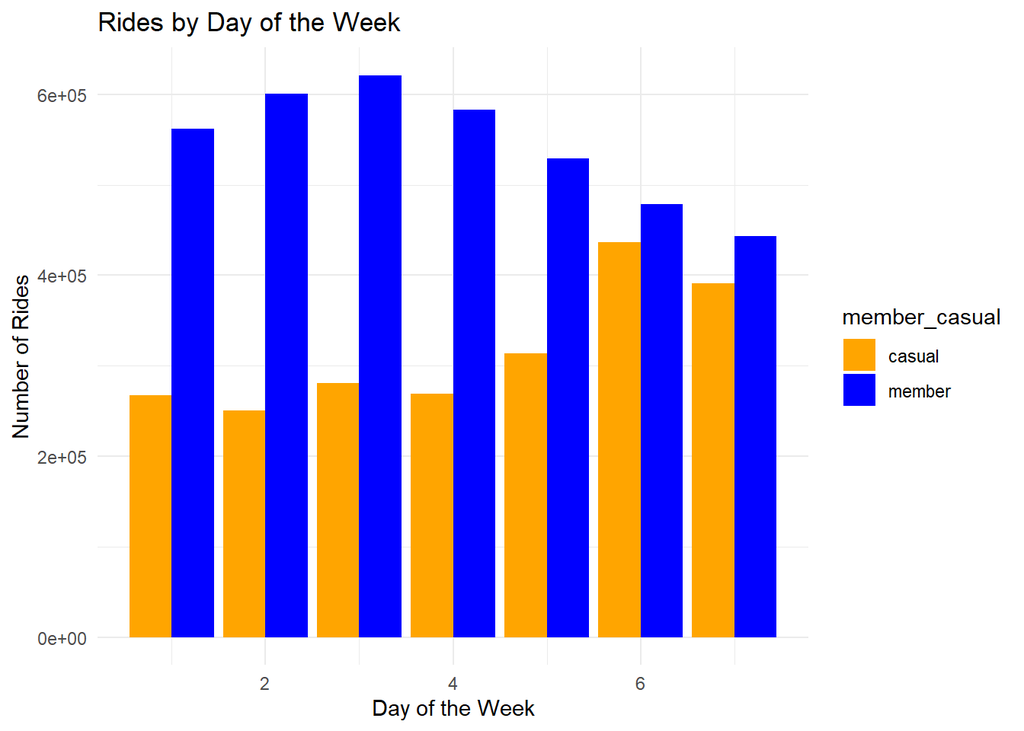

```r
ggplot(all_data, aes(x = day_of_week , fill = member_casual)) +
  geom_bar(position = "dodge") +
  labs(title = "Rides by Day of the Week",
       x = "Day of the Week",
       y = "Number of Rides") +
  scale_fill_manual(values = c("casual" = "orange", "member" = "blue")) +
  theme_minimal()
```

#### Popular Start Times for Rides:

```r
# Check the data type of start_time
class(all_data$start_time) # This shows the data type
```

```
## [1] "character"
```

```r
# Check the structure and format of start_time
str(all_data$start_time) # This shows detailed information about the format and type
```

```
##  chr [1:6028973] "10:36:26" "17:23:59" "07:02:33" "19:13:03" "18:19:26" ...
```

```r
head(rides_by_hour)
```

```
## # A tibble: 6 × 3
## # Groups:   member_casual [1]
##   member_casual start_hour total_rides
##   <chr>              <dbl>       <int>
## 1 casual                 0       36139
## 2 casual                 1       24153
## 3 casual                 2       15030
## 4 casual                 3        8444
## 5 casual                 4        6305
## 6 casual                 5       12514
```

```r
# Check unique values for start_hour and member_casual
print(unique(rides_by_hour$start_hour))
```

```
##  [1]  0  1  2  3  4  5  6  7  8  9 10 11 12 13 14 15 16 17 18 19 20 21 22 23
```

```r
print(unique(rides_by_hour$member_casual))
```

```
## [1] "casual" "member"
```

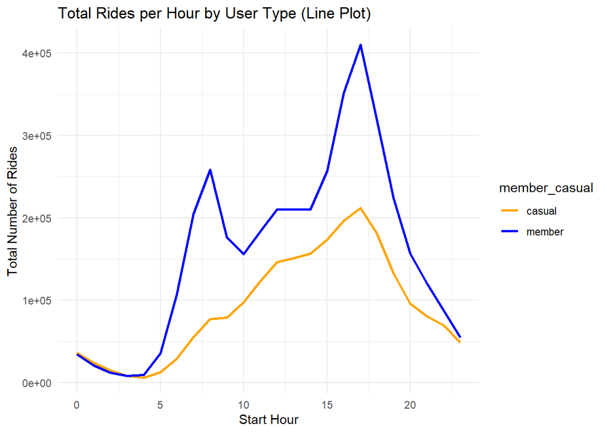

```r
# Line Plot: Total number of rides per hour by user type (casual vs. member)
ggplot(rides_by_hour, aes(x = start_hour, y = total_rides, color = member_casual, group = member_casual)) +
  geom_line(size = 1) +  # Line plot
  labs(title = "Total Rides per Hour by User Type (Line Plot)",
       x = "Start Hour",
       y = "Total Number of Rides") +
  scale_color_manual(values = c("casual" = "orange", "member" = "blue")) +
  theme_minimal()
```

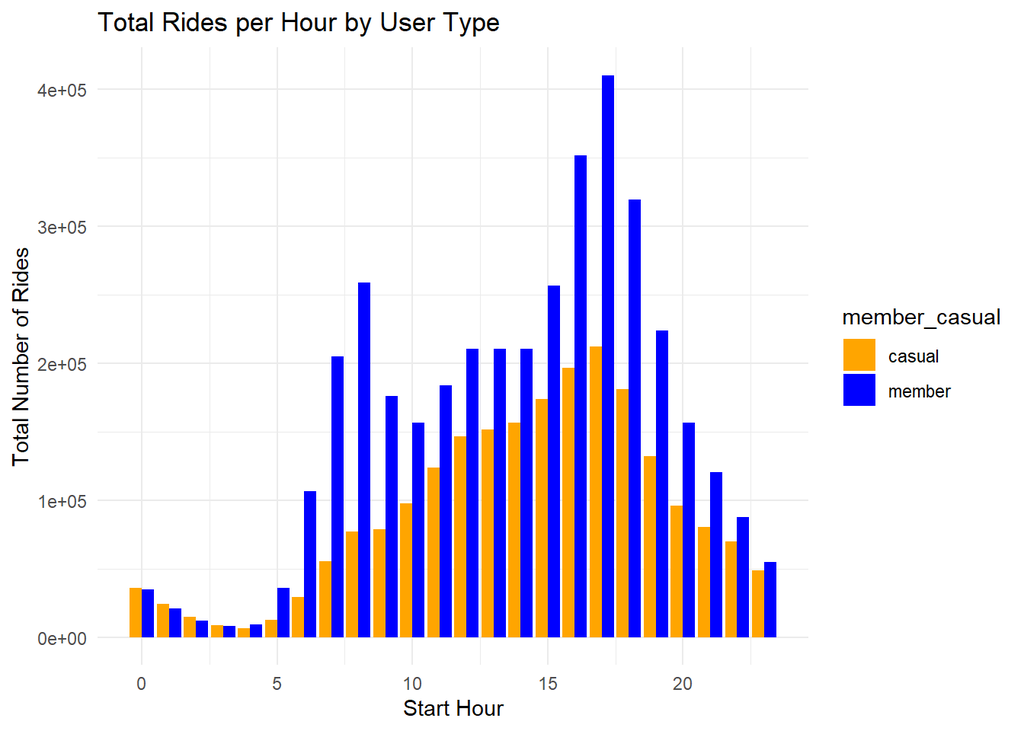

```r
# Bar Plot: Total number of rides per hour, split by user type (casual vs. member)
ggplot(rides_by_hour, aes(x = start_hour, y = total_rides, fill = member_casual)) +
  geom_bar(stat = "identity", position = "dodge") +  # Bar plot with dodged bars
  labs(title = "Total Rides per Hour by User Type",
       x = "Start Hour",
       y = "Total Number of Rides") +
  scale_fill_manual(values = c("casual" = "orange", "member" = "blue")) +
  theme_minimal()
```

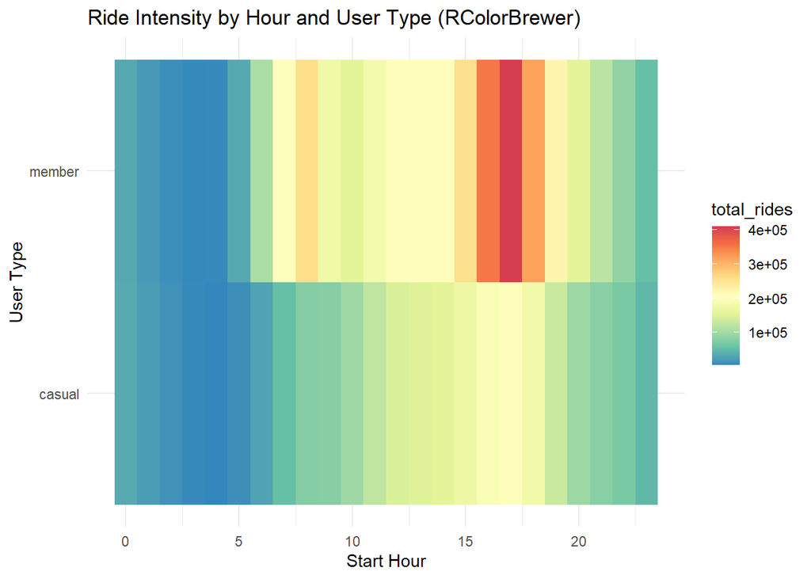

```r
# Install and load RColorBrewer package (if not installed yet)
# install.packages("RColorBrewer")
library(RColorBrewer)

# Heatmap with RColorBrewer palette (Spectral)
ggplot(rides_by_hour, aes(x = start_hour, y = member_casual, fill = total_rides)) +
  geom_tile() +  # Heatmap
  labs(title = "Ride Intensity by Hour and User Type (RColorBrewer)",
       x = "Start Hour",
       y = "User Type") +
  scale_fill_gradientn(colors = rev(brewer.pal(9, "Spectral"))) +  # Using a predefined color palette
  theme_minimal()
```

#### Insights from Plots and Findings

Rides by Day of the Week:

The plot displays a clear distinction in ride patterns across weekdays and weekends. Casual riders’ activity peaks on Saturdays, while members’ rides are more evenly distributed throughout the week with a peak on Wednesday.

Casual riders prefer weekends, suggesting a recreational usage pattern, while members’ steady weekday usage is indicative of utilitarian rides (e.g., commuting). Promotions geared toward weekend adventures and member-exclusive benefits on weekends might appeal to casual riders, encouraging them to sign up for membership for weekend discounts or perks.

#### Answering the Business Task

The analysis indicates that casual riders engage with Cyclistic for leisure-oriented activities while members demonstrate consistent, weekday-focused commuting behavior. To convert casual riders to members,

Cyclistic can employ the following strategies:

Targeted Promotional Campaigns:

Offer weekend and evening-based promotions that highlight the cost-effectiveness of a membership. This can help casual riders see how becoming a member aligns with their existing usage patterns.

Highlight Membership Benefits for Leisure Use:

Given the casual riders’ propensity for longer, leisurely rides, Cyclistic could introduce incentives like unlimited or discounted extended ride options exclusive to members.

Create Exclusive Weekend Perks:

With casual riders most active on Saturdays, Cyclistic might offer weekend deals for members or introduce special weekend ride benefits, creating an incentive for casual users to see the membership as valuable for their most active days.

In summary, these findings suggest a strategic pathway to encourage casual riders to become members by aligning membership benefits with casual riders’ existing habits—particularly focusing on extended ride lengths and weekend peak times.